# R 중급 통계분석 1일차 (3)

Sanghoo Yoon

# 자료 병합하기

두 개의 데이터 프레임 자료형이 있을 때, 이를 하나로 합치는 병합(Join) 방법에 대해 알아보겠습니다.

먼저, 병합(Join)을 할 두 개의 데이터 프레임을 준비해보겠습니다. 아래와 같이 데이터 테이블 자료형으로 Departments 과 Employees 을 만들어 봅시다.

```r
 # 두 개의 데이터 프레임 생성
Departments <- data.frame(Department = c(11, 12, 13, 14),
                           DepartmentName = c("Production", "Sales", "Marketing", "Research"),
                           Manager = c(1, 4, 5, NA))

Employees <-data.frame(Employee = c(1, 2, 3, 4, 5, 6),
                        EmployeeName = c("Alice", "Bob", "Carla", "Daniel", "Evelyn", "Ferdinand"),
                                        Department = c(11, 11, 12, 12, 13, 21),
                                        Salary = c(800, 600, 900, 1000, 800, 700))
Departments
```

```
##   Department DepartmentName Manager
## 1         11     Production       1
## 2         12          Sales       4
## 3         13      Marketing       5
## 4         14       Research      NA
```

```r
Employees
```

```
##   Employee EmployeeName Department Salary
## 1        1        Alice         11    800
## 2        2          Bob         11    600
## 3        3        Carla         12    900
## 4        4       Daniel         12   1000
## 5        5       Evelyn         13    800
## 6        6    Ferdinand         21    700
```

위의 두 개의 데이터 프레임을 살펴보면 Department 라는 컬럼이 공통적으로 있기 때문에 데이터 병합할 때, 키(Key)로 활용할 수 있음을 확인할 수 있습니다.

## 데이터 프레임 병합(JOIN) 구문 살펴보기

살펴볼 데이터 프레임 병합(JOIN) 구문들은 dplyr 패키지에 저장되어 있으며 종류는 아래표와 같습니다.

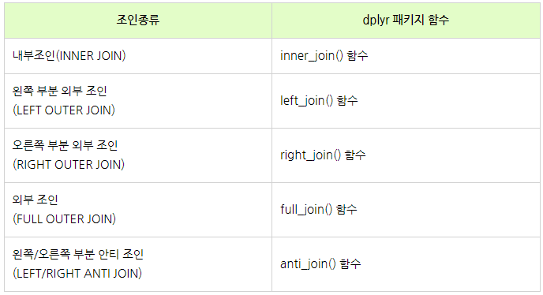

### 두 데이터 프레임 내부 조인(INNER JOIN) 하기 : dplyr 패키지의 inner_join() 함수

두 개의 데이터 프레임의 교집합만 추출하는 병합 방법입니다. 즉 Departments 데이터 테이블과 Employees 테이블의 Department 컬럼의 공통 원소를 추출하는 병합방법입니다.

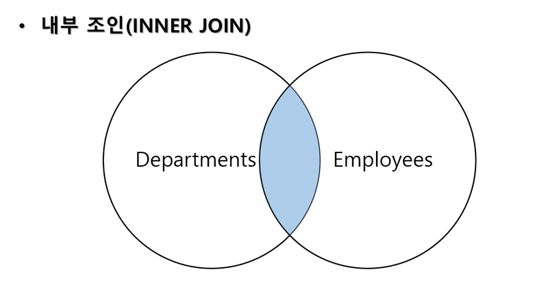

사용할 함수는 dplyr패키지의 inner_join() 함수이며 입력인자는 다음과 같습니다.

```
inner_join(x, y, by)

x %>% inner_join(y, by)
```

x : 원 데이터

y : 병합할 데이터

by : 병합 기준 변수 (Key), 만약 생략시 동일한 변수명을 기준으로 병합

그럼 Departments와 Employees을 내부 조인하여 봅시다.

```r
library(dplyr)
 inner_join(Departments, Employees, by ="Department")
```

```
##   Department DepartmentName Manager Employee EmployeeName Salary
## 1         11     Production       1        1        Alice    800
## 2         11     Production       1        2          Bob    600
## 3         12          Sales       4        3        Carla    900
## 4         12          Sales       4        4       Daniel   1000
## 5         13      Marketing       5        5       Evelyn    800
```

```r
Departments %>% inner_join(Employees, by ="Department")
```

```
##   Department DepartmentName Manager Employee EmployeeName Salary
## 1         11     Production       1        1        Alice    800
## 2         11     Production       1        2          Bob    600
## 3         12          Sales       4        3        Carla    900
## 4         12          Sales       4        4       Daniel   1000
## 5         13      Marketing       5        5       Evelyn    800
```

```r
Departments %>% inner_join(Employees)
```

```
##   Department DepartmentName Manager Employee EmployeeName Salary
## 1         11     Production       1        1        Alice    800
## 2         11     Production       1        2          Bob    600
## 3         12          Sales       4        3        Carla    900
## 4         12          Sales       4        4       Daniel   1000
## 5         13      Marketing       5        5       Evelyn    800
```

### 두 데이터 프레임 왼쪽 부분 외부조인(LEFT OUTER JOIN) 하기 : dplyr 패키지의 left_join() 함수

왼쪽 부분 외부조인은 기준 데이터 프레임의 값 + 중복된 값을 보여줍니다. 즉, 왼쪽 데이터 프레임을 기준으로 조인하는 방법입니다.

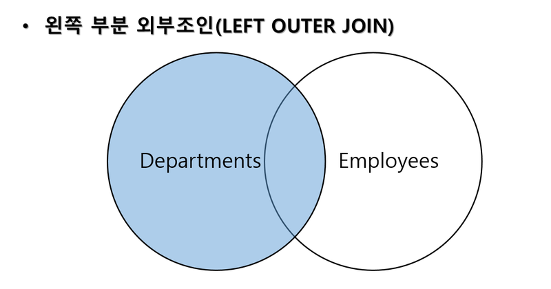

사용할 함수는 dplyr패키지의 left_join() 함수이며 입력인자는 위의 inner_join() 함수와 같습니다.

```
left_join(x, y, by)

x %>% left_join(y, by)
```

```r
left_join(Departments, Employees, by = "Department")
```

```
##   Department DepartmentName Manager Employee EmployeeName Salary
## 1         11     Production       1        1        Alice    800
## 2         11     Production       1        2          Bob    600
## 3         12          Sales       4        3        Carla    900
## 4         12          Sales       4        4       Daniel   1000
## 5         13      Marketing       5        5       Evelyn    800
## 6         14       Research      NA       NA         <NA>     NA
```

```r
Departments %>% left_join(Employees, by = "Department")
```

```
##   Department DepartmentName Manager Employee EmployeeName Salary
## 1         11     Production       1        1        Alice    800
## 2         11     Production       1        2          Bob    600
## 3         12          Sales       4        3        Carla    900
## 4         12          Sales       4        4       Daniel   1000
## 5         13      Marketing       5        5       Evelyn    800
## 6         14       Research      NA       NA         <NA>     NA
```

만약, right_join을 이용하면 두번째 데이터를 기준으로 병합하게 됩니다.

```r
right_join(Departments, Employees, by = "Department")
```

```
##   Department DepartmentName Manager Employee EmployeeName Salary
## 1         11     Production       1        1        Alice    800
## 2         11     Production       1        2          Bob    600
## 3         12          Sales       4        3        Carla    900
## 4         12          Sales       4        4       Daniel   1000
## 5         13      Marketing       5        5       Evelyn    800
## 6         21           <NA>      NA        6    Ferdinand    700
```

```r
Departments %>% right_join(Employees, by = "Department")
```

```
##   Department DepartmentName Manager Employee EmployeeName Salary
## 1         11     Production       1        1        Alice    800
## 2         11     Production       1        2          Bob    600
## 3         12          Sales       4        3        Carla    900
## 4         12          Sales       4        4       Daniel   1000
## 5         13      Marketing       5        5       Evelyn    800
## 6         21           <NA>      NA        6    Ferdinand    700
```

### 두 데이터 프레임 외부조인(FULL OUTER JOIN) 하기 : dplyr 패키지의 full_join() 함수

쉽게 말해서 합집합 개념으로 생각하시면 됩니다. 두 개의 데이터 프레임들이 가지고 있는 데이터를 모두 병합한다고 생각하시면 됩니다.

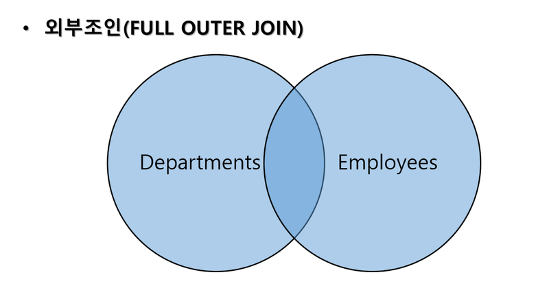

사용할 함수는 dplyr패키지의 full_join() 함수이며 입력인자는 위의 inner_join() 함수와 같습니다.

```
full_join(x, y, by)

x %>% full_join(y, by)
```

```r
full_join(Departments, Employees, by ="Department")
```

```
##   Department DepartmentName Manager Employee EmployeeName Salary
## 1         11     Production       1        1        Alice    800
## 2         11     Production       1        2          Bob    600
## 3         12          Sales       4        3        Carla    900
## 4         12          Sales       4        4       Daniel   1000
## 5         13      Marketing       5        5       Evelyn    800
## 6         14       Research      NA       NA         <NA>     NA
## 7         21           <NA>      NA        6    Ferdinand    700
```

```r
Departments %>% full_join(Employees, by ="Department")
```

```
##   Department DepartmentName Manager Employee EmployeeName Salary
## 1         11     Production       1        1        Alice    800
## 2         11     Production       1        2          Bob    600
## 3         12          Sales       4        3        Carla    900
## 4         12          Sales       4        4       Daniel   1000
## 5         13      Marketing       5        5       Evelyn    800
## 6         14       Research      NA       NA         <NA>     NA
## 7         21           <NA>      NA        6    Ferdinand    700
```

### 두 데이터 프레임 왼쪽/오른쪽 안티 조인(LEFT ANTI JOIN) 하기 : dplyr 패키지의 anti_join() 함수

[figure not shown]

사용할 함수는 anti_join() 함수이고 기준이 되는 Deparment를 x 입력인자에 입력하고 Employees를 y입력인자에 입력합니다.

```r
anti_join(Departments, Employees, by = "Department")
```

```
##   Department DepartmentName Manager
## 1         14       Research      NA
```

```r
Departments %>% anti_join( Employees, by = "Department")
```

```
##   Department DepartmentName Manager
## 1         14       Research      NA
```

```r
anti_join(Employees, Departments, by = "Department")
```

```
##   Employee EmployeeName Department Salary
## 1        6    Ferdinand         21    700
```

```r
Employees %>% anti_join(Departments, by = "Department")
```

```
##   Employee EmployeeName Department Salary
## 1        6    Ferdinand         21    700
```

### 병합 기준 (Key)의 이름이 다르면?

다음과 같이 두 개의 데이터가 있다고 하겠습니다.

```r
# 두 개의 데이터 프레임 생성
Departments <- data.frame(Division = c(11, 12, 13, 14),
                           DepartmentName = c("Production", "Sales", "Marketing", "Research"),
                           Manager = c(1, 4, 5, NA))

Employees <-data.frame(Employee = c(1, 2, 3, 4, 5, 6),
                        EmployeeName = c("Alice", "Bob", "Carla", "Daniel", "Evelyn", "Ferdinand"),
                                        Department = c(11, 11, 12, 12, 13, 21),
                       Salary = c(800, 600, 900, 1000, 800, 700))
```

병합 기준은 Departments에서 `Division`이고 Employees에서는 ’Department’입니다.

병합 기준이 없으므로 다음 실행 코드는 오류가 발생하며 결과를 출력하지 못합니다.

```r
Departments %>% inner_join(Employees)
```

이 경우에는 `by=c("Division"="Department")`을 이용하여 Division과 Department가 동일 변수임을 알려줘야 합니다.

```r
Departments %>% inner_join(Employees, by=c("Division"="Department"))
```

```
##   Division DepartmentName Manager Employee EmployeeName Salary
## 1       11     Production       1        1        Alice    800
## 2       11     Production       1        2          Bob    600
## 3       12          Sales       4        3        Carla    900
## 4       12          Sales       4        4       Daniel   1000
## 5       13      Marketing       5        5       Evelyn    800
```

## join을 수행하는 다른 방법

R에 내장되어 있는 기본함수인 `merge`를 이용하면 inner_join, left_join, right_join, full_join을 수행할 수 있습니다.

```r
merge(Departments, Employees, by.x="Division", by.y="Department") # inner_join
```

```
##   Division DepartmentName Manager Employee EmployeeName Salary
## 1       11     Production       1        1        Alice    800
## 2       11     Production       1        2          Bob    600
## 3       12          Sales       4        3        Carla    900
## 4       12          Sales       4        4       Daniel   1000
## 5       13      Marketing       5        5       Evelyn    800
```

```r
merge(Departments, Employees, by.x="Division", by.y="Department", all.x=T) # left_join
```

```
##   Division DepartmentName Manager Employee EmployeeName Salary
## 1       11     Production       1        1        Alice    800
## 2       11     Production       1        2          Bob    600
## 3       12          Sales       4        3        Carla    900
## 4       12          Sales       4        4       Daniel   1000
## 5       13      Marketing       5        5       Evelyn    800
## 6       14       Research      NA       NA         <NA>     NA
```

```r
merge(Departments, Employees, by.x="Division", by.y="Department", all.y=T) # right_join
```

```
##   Division DepartmentName Manager Employee EmployeeName Salary
## 1       11     Production       1        1        Alice    800
## 2       11     Production       1        2          Bob    600
## 3       12          Sales       4        3        Carla    900
## 4       12          Sales       4        4       Daniel   1000
## 5       13      Marketing       5        5       Evelyn    800
## 6       21           <NA>      NA        6    Ferdinand    700
```

```r
merge(Departments, Employees, by.x="Division", by.y="Department", all=T) # full_join
```

```
##   Division DepartmentName Manager Employee EmployeeName Salary
## 1       11     Production       1        1        Alice    800
## 2       11     Production       1        2          Bob    600
## 3       12          Sales       4        3        Carla    900
## 4       12          Sales       4        4       Daniel   1000
## 5       13      Marketing       5        5       Evelyn    800
## 6       14       Research      NA       NA         <NA>     NA
## 7       21           <NA>      NA        6    Ferdinand    700
```

## 예제 문제

`fortune1970.csv`, `fortune2000.csv`미국의 대형 기업들 정보가 담긴 fortune지에서 1970년과 2000년 기업 정보를 다운 받은 자료입니다.

1 1970~2000 간 유지되고 있는 기업 리스트는?

2 1970~2000 사이 매출액의 증가율 (Revenues at 2020/Revenues at 1970)이 높은 기업 5개의 리스트와 매출액 증가율은?

3 1970~2000 사이 새로 유입된 대형 기업 수는?